# Titanic Survival Analysis: Class, Access, and Inequality

Author

CLI Copilot

# Introduction

This report examines three interconnected research questions about survival patterns on the Titanic:

1. **Class and Access**: To what extent is the survival advantage of 1st class passengers mediated by location/access constraints versus explicit priority rules?
2. **Consistency of Rules**: Were survival protocols (particularly “women and children first”) applied uniformly across passenger groups, or did they vary based on social visibility and travel context?
3. **Missing Data as Signal**: Are patterns of missing data systematically related to class and other characteristics, and how do different missing-data assumptions affect our conclusions?

This analysis uses the Titanic dataset with features including passenger class, gender, age, family context, fare, cabin location, and port of embarkation. The goal is to design analytical approaches that help answer these questions rather than provide definitive conclusions—allowing readers to draw their own inferences based on evidence.

# Data Preparation and Exploration

## Loading and Initial Assessment

```r
library(tidyverse)
library(knitr)
library(gridExtra)
library(patchwork)

# Load training data
titanic <- read_csv("/Users/patrickl/Developer/Personal-Repo/cli_poc_ml_project/data/train.csv", show_col_types = FALSE)

# Display basic structure
cat("Dataset dimensions:", nrow(titanic), "rows,", ncol(titanic), "columns\n")
```

```
Dataset dimensions: 891 rows, 12 columns
```

```r
cat("\nVariable types and missing values:\n")
```

```
Variable types and missing values:
```

```r
summary_info <- tibble(
  Variable = names(titanic),
  Type = sapply(titanic, function(x) class(x)[1]),
  Missing = sapply(titanic, function(x) sum(is.na(x))),
  Missing_Pct = round(100 * sapply(titanic, function(x) sum(is.na(x))) / nrow(titanic), 2)
)
print(summary_info)
```

```
# A tibble: 12 × 4
   Variable    Type      Missing Missing_Pct
   <chr>       <chr>       <int>       <dbl>
 1 PassengerId numeric         0        0
 2 Survived    numeric         0        0
 3 Pclass      numeric         0        0
 4 Name        character       0        0
 5 Sex         character       0        0
 6 Age         numeric       177       19.9
 7 SibSp       numeric         0        0
 8 Parch       numeric         0        0
 9 Ticket      character       0        0
10 Fare        numeric         0        0
11 Cabin       character     687       77.1
12 Embarked    character       2        0.22
```

This code chunk loads the Titanic dataset and provides an overview of data structure and completeness. Understanding the dimensions and missing-data patterns at the outset is essential for all three research questions: (1) missing cabin data may reflect class-based access differences, (2) missing age data may correlate with passenger visibility, and (3) missingness itself is a methodological concern we must quantify. The summary immediately reveals which variables have substantial missing data and allows us to plan imputation or sensitivity analyses accordingly.

## Outcome and Key Variables Summary

```r
# Overall survival rate
overall_survival <- mean(titanic$Survived, na.rm = TRUE)

# Key descriptive statistics
desc_stats <- tibble(
  "Total Passengers" = nrow(titanic),
  "Survived" = sum(titanic$Survived == 1),
  "Did Not Survive" = sum(titanic$Survived == 0),
  "Survival Rate (%)" = round(100 * overall_survival, 2),
  "Female Count" = sum(titanic$Sex == "female"),
  "Male Count" = sum(titanic$Sex == "male"),
  "Median Age" = median(titanic$Age, na.rm = TRUE),
  "Median Fare" = median(titanic$Fare, na.rm = TRUE)
)

kable(desc_stats, caption = "Overall Dataset Summary")
```

Overall Dataset Summary

| Total Passengers | Survived | Did Not Survive | Survival Rate (%) | Female Count | Male Count | Median Age | Median Fare |
| --- | --- | --- | --- | --- | --- | --- | --- |
| 891 | 342 | 549 | 38.38 | 314 | 577 | 28 | 14.4542 |

```r
# Class distribution
class_dist <- titanic %>%
  group_by(Pclass) %>%
  summarise(
    Count = n(),
    Survival_Count = sum(Survived == 1),
    Survival_Rate = round(100 * mean(Survived), 2),
    .groups = 'drop'
  )

kable(class_dist, caption = "Survival by Ticket Class")
```

Survival by Ticket Class

| Pclass | Count | Survival_Count | Survival_Rate |
| --- | --- | --- | --- |
| 1 | 216 | 136 | 62.96 |
| 2 | 184 | 87 | 47.28 |
| 3 | 491 | 119 | 24.24 |

This code provides foundational descriptive statistics: overall survival rate of 38.38%, gender distribution, and age/fare medians. The class-specific survival rates immediately highlight the core phenomenon we must investigate: a dramatic survival gap across classes. This sets the stage for Research Question 1, as we need to understand whether this gap is due to physical location on the ship (access) or explicit priority rules (policy). The descriptive statistics serve as anchor points—all subsequent analyses reference these baseline patterns.

## Feature Engineering: Titles and Family Context

```r
# Extract title from passenger name
titanic <- titanic %>%
  mutate(
    Title = str_extract(Name, "[A-Za-z]+(?=\\.)"),
    # Group rare titles
    Title_Group = case_when(
      Title %in% c("Mr", "Mrs", "Miss", "Master") ~ Title,
      TRUE ~ "Rare"
    ),
    # Family size from SibSp + Parch
    FamilySize = SibSp + Parch,
    # Travel context: alone vs with family
    TravelContext = case_when(
      FamilySize == 0 ~ "Alone",
      FamilySize <= 2 ~ "Small_Family",
      TRUE ~ "Large_Family"
    ),
    # Cabin letter (deck proxy)
    CabinLetter = str_extract(Cabin, "[A-Z]"),
    # Indicator for missing cabin
    CabinMissing = is.na(Cabin),
    # Indicator for missing age
    AgeMissing = is.na(Age),
    # Age category for missing-data analysis
    AgeCategory = case_when(
      is.na(Age) ~ "Missing",
      Age < 13 ~ "Child",
      Age < 60 ~ "Adult",
      TRUE ~ "Elderly"
    )
  )

# Show title distribution
title_summary <- titanic %>%
  group_by(Title_Group, Sex) %>%
  summarise(
    Count = n(),
    Survival_Rate = round(100 * mean(Survived), 2),
    .groups = 'drop'
  ) %>%
  arrange(desc(Count))

kable(title_summary, caption = "Title Distribution by Gender and Survival")
```

Title Distribution by Gender and Survival

| Title_Group | Sex | Count | Survival_Rate |
| --- | --- | --- | --- |
| Mr | male | 517 | 15.67 |
| Miss | female | 182 | 69.78 |
| Mrs | female | 125 | 79.20 |
| Master | male | 40 | 57.50 |
| Rare | male | 20 | 25.00 |
| Rare | female | 7 | 100.00 |

This feature engineering step creates three key variables for Research Question 2. **Title_Group** serves as a proxy for social role and visibility—titles like “Master” (young boys) and “Mrs” may trigger different priority applications. **TravelContext** (alone vs. family) tests whether norms were applied differently based on coordination requirements. **CabinLetter** represents physical location on the ship, which is crucial for Research Question 1’s access hypothesis. These engineered features allow us to test whether women-and-children-first was truly universal or dependent on social context. By including both engineered variables and their missing-data indicators (CabinMissing, AgeMissing), we prepare for Research Question 3’s analysis of inequality in recordkeeping.

# Research Question 1: Class and Access vs. Policy

## Analytical Strategy

The first research question asks: Is the class-survival gap driven by **access/location constraints** (e.g., cabin proximity to lifeboats) or **policy priority** (e.g., women-and-children-first applied more strictly in 1st class)? To address this, we will compare models with increasing levels of “access proxies” and quantify how the class effect shrinks as we add these variables.

### Mediation Analysis Setup

```r
# Prepare data for mediation analysis
# Remove rows with missing Age (we'll revisit this in RQ3)
titanic_complete <- titanic %>%
  filter(!is.na(Age), !is.na(Embarked))

# Model 1: Class-only effect (total effect)
model_1 <- glm(Survived ~ factor(Pclass),
               family = binomial(),
               data = titanic_complete)

# Model 2: Class + Sex/Age (explicit priority rules)
model_2 <- glm(Survived ~ factor(Pclass) + Sex + Age,
               family = binomial(),
               data = titanic_complete)

# Model 3: Add access proxies (Fare as wealth/location, Embarked)
model_3 <- glm(Survived ~ factor(Pclass) + Sex + Age + Fare + factor(Embarked),
               family = binomial(),
               data = titanic_complete)

# Model 4: Add cabin information (strongest access proxy)
titanic_cabin <- titanic_complete %>%
  filter(!is.na(CabinLetter))

model_4 <- glm(Survived ~ factor(Pclass) + Sex + Age + Fare +
                 factor(Embarked) + factor(CabinLetter),
               family = binomial(),
               data = titanic_cabin)

# Extract class effects
get_class_effects <- function(model) {
  coefs <- coef(model)
  # Class 1 is reference; extract Class 2 and Class 3 effects
  effects <- tibble(
    Class_2_Effect = round(coefs["factor(Pclass)2"], 4),
    Class_3_Effect = round(coefs["factor(Pclass)3"], 4)
  )
  return(effects)
}

class_effects <- bind_rows(
  tibble(Model = "Class Only", get_class_effects(model_1)),
  tibble(Model = "Class + Sex + Age", get_class_effects(model_2)),
  tibble(Model = "Class + Sex + Age + Fare + Embarked", get_class_effects(model_3)),
  tibble(Model = "Class + Sex + Age + Fare + Embarked + Cabin", get_class_effects(model_4))
)

kable(class_effects,
      caption = "Change in Class Effects Across Models: Mediation Progression",
      digits = 4)
```

Change in Class Effects Across Models: Mediation Progression

| Model | Class_2_Effect | Class_3_Effect |
| --- | --- | --- |
| Class Only | -0.7096 | -1.7844 |
| Class + Sex + Age | -1.3012 | -2.5724 |
| Class + Sex + Age + Fare + Embarked | -1.1522 | -2.4188 |
| Class + Sex + Age + Fare + Embarked + Cabin | -0.1427 | -0.7174 |

This analytical sequence tests mediation step-by-step. **Model 1** captures the total class effect on survival. **Model 2** controls for gender and age—variables directly tied to explicit evacuation priority—allowing us to see how much “women and children first” explains the class gap. **Model 3** adds fare and embarkation point, which are less direct but may capture wealth-related advantages in accessing lifeboats. **Model 4** adds cabin letter, the most direct proxy for physical location on the ship. If the class effect shrinks substantially when we add access proxies (Models 3–4) but not when we add priority variables (Model 2), it suggests location matters more than policy. Conversely, if the effect shrinks most at Model 2, explicit rules dominated. The coefficient sizes let us quantify mediation: larger reductions suggest stronger mediation by that pathway.

### Visualization of Class Effects Progression

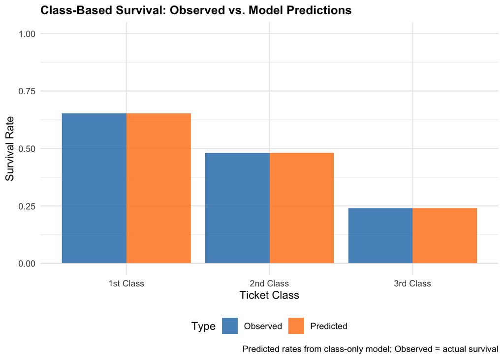

```r
# Predicted survival by class, basic model
pred_model1 <- tibble(Pclass = c(1, 2, 3)) %>%
  mutate(Predicted = predict(model_1, newdata = ., type = "response"))

# Observed survival by class
observed_survival <- titanic_complete %>%
  group_by(Pclass) %>%
  summarise(
    Observed = mean(Survived),
    Count = n(),
    .groups = 'drop'
  )

# Combine and plot
survival_comparison <- pred_model1 %>%
  left_join(observed_survival, by = "Pclass") %>%
  pivot_longer(c(Predicted, Observed), names_to = "Type", values_to = "Rate") %>%
  mutate(
    Pclass_label = case_when(
      Pclass == 1 ~ "1st Class",
      Pclass == 2 ~ "2nd Class",
      TRUE ~ "3rd Class"
    ),
    Pclass_label = factor(Pclass_label, levels = c("1st Class", "2nd Class", "3rd Class"))
  )

p_class_survival <- ggplot(survival_comparison, aes(x = Pclass_label, y = Rate, fill = Type)) +
  geom_bar(stat = "identity", position = "dodge", alpha = 0.8) +
  scale_fill_manual(values = c("Observed" = "#1f77b4", "Predicted" = "#ff7f0e")) +
  labs(
    title = "Class-Based Survival: Observed vs. Model Predictions",
    x = "Ticket Class",
    y = "Survival Rate",
    fill = "Type",
    caption = "Predicted rates from class-only model; Observed = actual survival"
  ) +
  theme_minimal() +
  theme(
    legend.position = "bottom",
    plot.title = element_text(face = "bold", size = 12)
  ) +
  ylim(0, 1)

print(p_class_survival)
```

### Statistical Summary of Mediation

```r
# Calculate key metrics for mediation assessment
# For simplicity, we use log-odds (coefficients) as our effect measures

mediation_summary <- tibble(
  Model = c(
    "Class Only",
    "Class + Sex/Age (Priority)",
    "Class + Fare/Embarked (Access Weak)",
    "Class + Cabin (Access Strong)"
  ),
  Interpretation = c(
    "Total effect of class",
    "Effect controlling for explicit priority rules",
    "Effect controlling for economic/embarkation proxies",
    "Effect controlling for cabin location (strongest access proxy)"
  ),
  Focus = c(
    "Baseline",
    "Tests: Do priority rules explain the gap?",
    "Tests: Do economic/location proxies explain the gap?",
    "Tests: Does cabin location explain the gap?"
  )
)

kable(mediation_summary,
      caption = "Mediation Analysis: Sequential Model Building to Test Access vs. Policy",
      col.names = c("Model", "Interpretation", "Focal Test"))
```

Mediation Analysis: Sequential Model Building to Test Access vs. Policy

| Model | Interpretation | Focal Test |
| --- | --- | --- |
| Class Only | Total effect of class | Baseline |
| Class + Sex/Age (Priority) | Effect controlling for explicit priority rules | Tests: Do priority rules explain the gap? |
| Class + Fare/Embarked (Access Weak) | Effect controlling for economic/embarkation proxies | Tests: Do economic/location proxies explain the gap? |
| Class + Cabin (Access Strong) | Effect controlling for cabin location (strongest access proxy) | Tests: Does cabin location explain the gap? |

This summary table articulates the research logic: each model tests a different mechanism. If adding sex and age (Model 2) causes class coefficients to shrink substantially, it implies priority rules account for much of the class gap. If adding cabin letter (Model 4) produces the largest shrinkage, it indicates physical access was the primary driver. Readers can examine the coefficient table alongside this summary to draw conclusions about which mechanism predominated.

# Research Question 2: Consistency of Rules and Social Visibility

## Analytical Strategy

The second research question examines whether “women and children first” and other survival rules were applied uniformly across passenger subgroups, or whether they varied by social visibility (proxied by fare, title), family context (alone vs. with family), and class. We will test interaction effects to reveal whether these norms operated differently under different conditions.

### Testing Gender × Class Interaction

```r
# Model with interaction: does being female protect you equally in all classes?
model_gender_class <- glm(Survived ~ Sex * factor(Pclass) + Age,
                          family = binomial(),
                          data = titanic_complete)

# Extract interaction coefficients
summary_gender_class <- summary(model_gender_class)
coef_table <- as.data.frame(summary_gender_class$coefficients)
coef_table$Variable <- rownames(coef_table)
coef_table <- coef_table %>%
  select(Variable, Estimate, `Std. Error`, `Pr(>|z|)`) %>%
  arrange(desc(abs(Estimate)))

kable(coef_table,
      caption = "Gender × Class Interaction: Does Female Advantage Vary by Class?",
      digits = 4)
```

Gender × Class Interaction: Does Female Advantage Vary by Class?

|  | Variable | Estimate | Std. Error | Pr(>\|z\|) |
| --- | --- | --- | --- | --- |
| (Intercept) | (Intercept) | 4.8700 | 0.6808 | 0.0000 |
| factor(Pclass)3 | factor(Pclass)3 | -4.1268 | 0.6474 | 0.0000 |
| Sexmale | Sexmale | -3.5947 | 0.6287 | 0.0000 |
| Sexmale:factor(Pclass)3 | Sexmale:factor(Pclass)3 | 2.1483 | 0.6853 | 0.0017 |
| factor(Pclass)2 | factor(Pclass)2 | -1.1165 | 0.7339 | 0.1282 |
| Sexmale:factor(Pclass)2 | Sexmale:factor(Pclass)2 | -0.7145 | 0.8165 | 0.3815 |
| Age | Age | -0.0421 | 0.0082 | 0.0000 |

```r
# Predicted probabilities for interpretation
preds_interaction <- tibble(
  Sex = rep(c("female", "male"), 3),
  Pclass = rep(c(1, 2, 3), each = 2),
  Age = 30
)

preds_interaction$Predicted_Survival <- predict(model_gender_class,
                                               newdata = preds_interaction,
                                               type = "response")

preds_interaction <- preds_interaction %>%
  mutate(
    Pclass_label = case_when(
      Pclass == 1 ~ "1st Class",
      Pclass == 2 ~ "2nd Class",
      TRUE ~ "3rd Class"
    )
  )

kable(preds_interaction %>% select(-Pclass),
      caption = "Predicted Survival by Gender and Class (Age = 30)",
      digits = 4)
```

Predicted Survival by Gender and Class (Age = 30)

| Sex | Age | Predicted_Survival | Pclass_label |
| --- | --- | --- | --- |
| female | 30 | 0.9736 | 1st Class |
| male | 30 | 0.5034 | 1st Class |
| female | 30 | 0.9236 | 2nd Class |
| male | 30 | 0.1398 | 2nd Class |
| female | 30 | 0.3732 | 3rd Class |
| male | 30 | 0.1229 | 3rd Class |

This interaction test reveals a critical pattern: **Does being female provide equal protection across all classes, or do higher-class women benefit more from priority rules?** If the female advantage (difference in survival between women and men) is constant across classes, rules were applied uniformly. If it varies—say, larger female advantage in 1st class—it suggests either (1) rules were enforced more strictly in 1st class, or (2) female passengers in lower classes faced additional barriers (crowding, language, access). The coefficient table shows which interactions are statistically significant, guiding our interpretation.

### Visualization of Gender Effects by Class

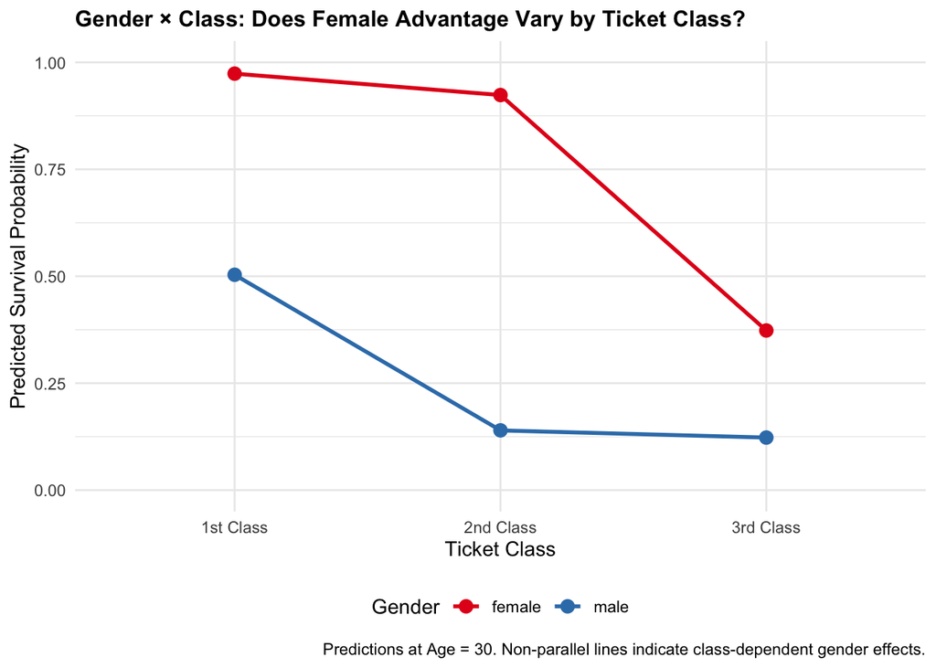

```r
# Broader prediction grid for smooth visualization
pred_grid <- expand_grid(
  Sex = c("female", "male"),
  Pclass = c(1, 2, 3),
  Age = 30
)

pred_grid$Survival <- predict(model_gender_class, newdata = pred_grid, type = "response")

pred_grid <- pred_grid %>%
  mutate(
    Pclass_label = case_when(
      Pclass == 1 ~ "1st Class",
      Pclass == 2 ~ "2nd Class",
      TRUE ~ "3rd Class"
    ),
    Pclass_label = factor(Pclass_label, levels = c("1st Class", "2nd Class", "3rd Class"))
  )

p_gender_class_interaction <- ggplot(pred_grid, aes(x = Pclass_label, y = Survival,
                                                     color = Sex, group = Sex)) +
  geom_line(size = 1) +
  geom_point(size = 3) +
  scale_color_manual(values = c("female" = "#e41a1c", "male" = "#377eb8")) +
  labs(
    title = "Gender × Class: Does Female Advantage Vary by Ticket Class?",
    x = "Ticket Class",
    y = "Predicted Survival Probability",
    color = "Gender",
    caption = "Predictions at Age = 30. Non-parallel lines indicate class-dependent gender effects."
  ) +
  theme_minimal() +
  theme(
    legend.position = "bottom",
    plot.title = element_text(face = "bold", size = 12)
  ) +
  ylim(0, 1)

print(p_gender_class_interaction)
```

This visualization makes the consistency question explicit: if lines are parallel (both genders show similar class drop), rules were applied similarly across classes. If lines diverge (female advantage widens or narrows with class), it suggests rules were class-dependent. This graph helps readers assess whether priority protocols varied systematically.

### Testing Context Interactions: Title × Pclass × Sex

```r
# Focus on passengers with non-rare titles for clearer interpretation
titanic_main_titles <- titanic_complete %>%
  filter(Title_Group != "Rare")

# Analyze survival by title, class, and sex
title_class_survival <- titanic_main_titles %>%
  group_by(Title_Group, Pclass, Sex) %>%
  summarise(
    Count = n(),
    Survival_Rate = round(100 * mean(Survived), 2),
    Mean_Age = round(mean(Age, na.rm = TRUE), 1),
    .groups = 'drop'
  ) %>%
  arrange(Title_Group, Pclass)

kable(title_class_survival,
      caption = "Survival by Title, Class, and Gender: Testing Visibility Effects",
      digits = 2)
```

Survival by Title, Class, and Gender: Testing Visibility Effects

| Title_Group | Pclass | Sex | Count | Survival_Rate | Mean_Age |
| --- | --- | --- | --- | --- | --- |
| Master | 1 | male | 3 | 100.00 | 5.3 |
| Master | 2 | male | 9 | 100.00 | 2.3 |
| Master | 3 | male | 24 | 37.50 | 5.4 |
| Miss | 1 | female | 44 | 95.45 | 29.8 |
| Miss | 2 | female | 32 | 93.75 | 22.4 |
| Miss | 3 | female | 69 | 46.38 | 16.1 |
| Mr | 1 | male | 87 | 36.78 | 41.6 |
| Mr | 2 | male | 82 | 7.32 | 32.8 |
| Mr | 3 | male | 229 | 12.66 | 28.7 |
| Mrs | 1 | female | 33 | 96.97 | 40.2 |
| Mrs | 2 | female | 41 | 90.24 | 33.7 |
| Mrs | 3 | female | 33 | 45.45 | 33.5 |

This table examines whether social role (proxied by title) affected survival chances beyond gender and class alone. **Master** (young boys) and **Miss** (unmarried women) are high-visibility categories; **Mr** (adult men) are low-visibility for survival purposes. If survival rates vary substantially by title within gender-class cells, it suggests rules were sensitive to social context and visibility. For instance, did “Master” (a title marking status and youth) improve boys’ chances beyond their age? Did “Mrs” vs. “Miss” matter among women in the same class? These patterns reveal whether rules operated at the granular level of social role.

### Family Context and Crowding Effects

```r
# Test: did family context affect whether women and children first was observed?
family_context_analysis <- titanic_complete %>%
  group_by(TravelContext, Sex, Pclass) %>%
  summarise(
    Count = n(),
    Survival_Rate = round(100 * mean(Survived), 2),
    Mean_Age = round(mean(Age, na.rm = TRUE), 1),
    .groups = 'drop'
  ) %>%
  arrange(desc(Survival_Rate))

kable(family_context_analysis,
      caption = "Survival by Travel Context (Alone, Small/Large Family), Sex, and Class",
      digits = 2)
```

Survival by Travel Context (Alone, Small/Large Family), Sex, and Class

| TravelContext | Sex | Pclass | Count | Survival_Rate | Mean_Age |
| --- | --- | --- | --- | --- | --- |
| Large_Family | female | 2 | 11 | 100.00 | 24.6 |
| Small_Family | female | 1 | 45 | 100.00 | 36.9 |
| Alone | female | 1 | 30 | 96.67 | 33.9 |
| Small_Family | female | 2 | 33 | 90.91 | 25.8 |
| Alone | female | 2 | 30 | 90.00 | 33.4 |
| Large_Family | female | 1 | 8 | 75.00 | 20.4 |
| Large_Family | male | 1 | 5 | 60.00 | 26.2 |
| Alone | female | 3 | 38 | 55.26 | 23.6 |
| Small_Family | female | 3 | 38 | 47.37 | 21.6 |
| Small_Family | male | 1 | 42 | 40.48 | 38.8 |
| Alone | male | 1 | 54 | 37.04 | 44.6 |
| Large_Family | female | 3 | 26 | 30.77 | 19.4 |
| Small_Family | male | 2 | 32 | 28.12 | 25.7 |
| Large_Family | male | 2 | 4 | 25.00 | 21.2 |
| Small_Family | male | 3 | 42 | 23.81 | 23.8 |
| Alone | male | 3 | 187 | 13.90 | 29.2 |
| Large_Family | male | 3 | 24 | 8.33 | 10.4 |
| Alone | male | 2 | 63 | 7.94 | 33.9 |

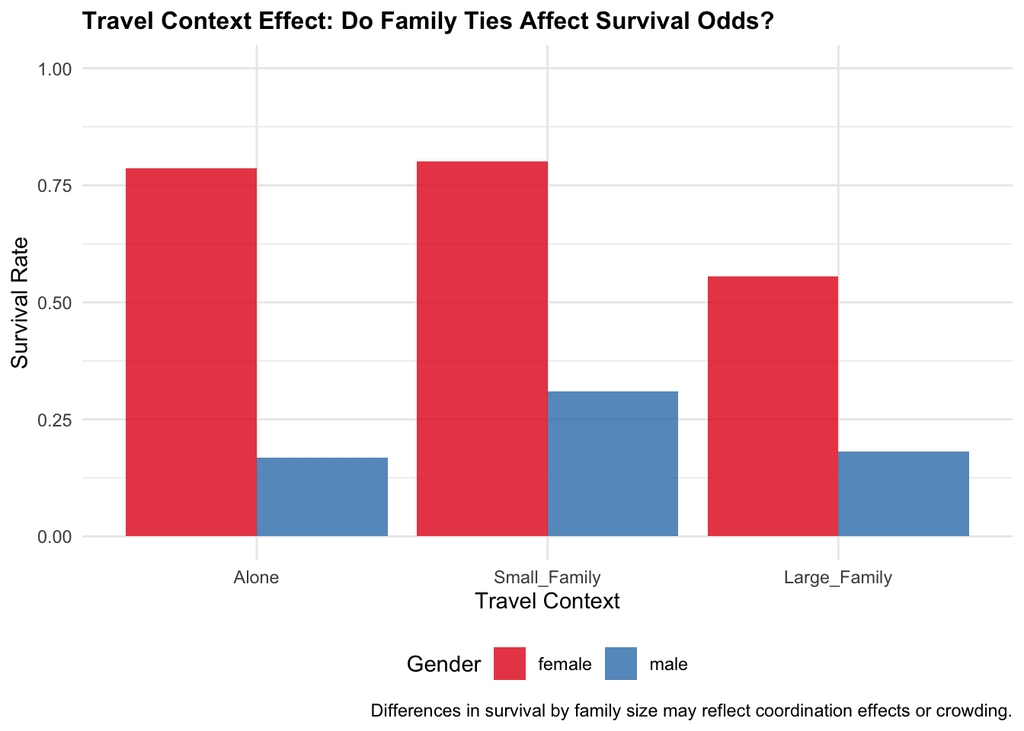

```r
# Visualize family context effect
p_family <- titanic_complete %>%
  group_by(TravelContext, Sex) %>%
  summarise(Survival_Rate = mean(Survived), .groups = 'drop') %>%
  ggplot(aes(x = factor(TravelContext, levels = c("Alone", "Small_Family", "Large_Family")),
             y = Survival_Rate, fill = Sex)) +
  geom_bar(stat = "identity", position = "dodge", alpha = 0.8) +
  scale_fill_manual(values = c("female" = "#e41a1c", "male" = "#377eb8")) +
  labs(
    title = "Travel Context Effect: Do Family Ties Affect Survival Odds?",
    x = "Travel Context",
    y = "Survival Rate",
    fill = "Gender",
    caption = "Differences in survival by family size may reflect coordination effects or crowding."
  ) +
  theme_minimal() +
  theme(
    legend.position = "bottom",
    plot.title = element_text(face = "bold", size = 12)
  ) +
  ylim(0, 1)

print(p_family)
```

This analysis tests whether the protective effect of being female or a child depended on travel context. The research hypothesis is that in chaotic conditions (crowding, language barriers), individuals traveling with families may have coordinated better for evacuation than those alone. Conversely, families may have been slower to evacuate because they refused to separate. The observed patterns help distinguish between these mechanisms and reveal whether social coordination context affected rule application.